# 6. Analysis of longitudinal data

## 1. RATS data

### a) Read in data:

```r
library(tidyr)
library(dplyr)
```

```r
library(ggplot2)
RATS <- read.csv("data/rats.csv", row.names = 1, header= TRUE)
RATS$ID <- factor(RATS$ID)
RATS$Group <- factor(RATS$Group)
summary(RATS)
```

```
##        ID      Group        WD         Weight           Time
##  1      : 11   1:88   WD1    :16   Min.   :225.0   Min.   : 1.00
##  2      : 11   2:44   WD15   :16   1st Qu.:267.0   1st Qu.:15.00
##  3      : 11   3:44   WD22   :16   Median :344.5   Median :36.00
##  4      : 11          WD29   :16   Mean   :384.5   Mean   :33.55
##  5      : 11          WD36   :16   3rd Qu.:511.2   3rd Qu.:50.00
##  6      : 11          WD43   :16   Max.   :628.0   Max.   :64.00
##  (Other):110          (Other):80
```

```r
str(RATS)
```

```
## 'data.frame':    176 obs. of  5 variables:
##  $ ID    : Factor w/ 16 levels "1","2","3","4",..: 1 2 3 4 5 6 7 8 9 10 ...
##  $ Group : Factor w/ 3 levels "1","2","3": 1 1 1 1 1 1 1 1 2 2 ...
##  $ WD    : Factor w/ 11 levels "WD1","WD15","WD22",..: 1 1 1 1 1 1 1 1 1 1 ...
##  $ Weight: int  240 225 245 260 255 260 275 245 410 405 ...
##  $ Time  : int  1 1 1 1 1 1 1 1 1 1 ...
```

This is data from a nutrition study conducted on three groups of rats. The groups were put on different diets, and each animal’s body weight (grams) was recorded repeatedly (approximately) weekly, except in week seven when two recordings were taken) over a 9-week period . Let’s create a graphical representation to understand the data better:

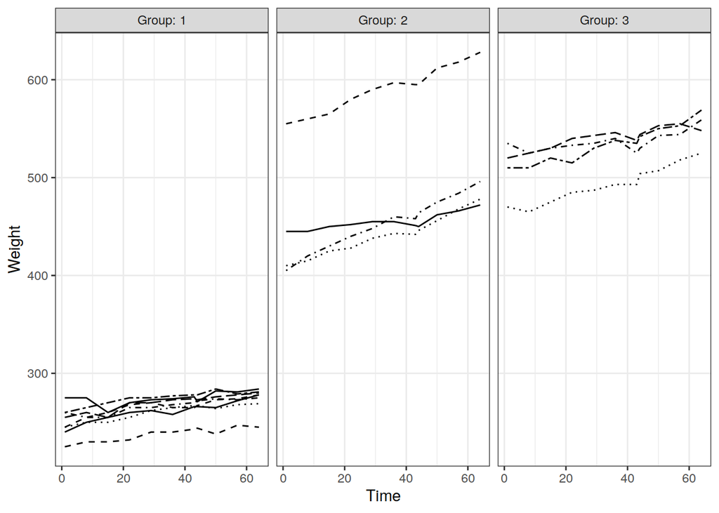

```r
p1 <- ggplot(RATS, aes(x = Time, y = Weight, linetype = ID))
p2 <- p1 + geom_line() + scale_linetype_manual(values = rep(1:10, times=4))
p3 <- p2 + facet_grid(. ~ Group, labeller = label_both)
p4 <- p3 + theme_bw() + theme(legend.position = "none")
p5 <- p4 + theme(panel.grid.minor.y = element_blank())
p6 <- p5 + scale_y_continuous(limits = c(min(RATS$Weight),max(RATS$Weight)))
p6
```

## b) Summarize Groups

```r
n <- RATS$Weight %>% unique() %>% length()

RATSS <- RATS %>% group_by(Group, Time) %>% summarise( mean=mean(Weight), se=sd(Weight)/sqrt(n)) %>% ungroup()
glimpse(RATSS)
```

```
## Rows: 33
## Columns: 4
## $ Group <fct> 1, 1, 1, 1, 1, 1, 1, 1, 1, 1, 1, 2, 2, 2, 2, 2, 2, 2, 2, 2, 2, …
## $ Time  <int> 1, 8, 15, 22, 29, 36, 43, 44, 50, 57, 64, 1, 8, 15, 22, 29, 36,…
## $ mean  <dbl> 250.625, 255.000, 254.375, 261.875, 264.625, 265.000, 267.375, …
## $ se    <dbl> 1.522158, 1.309307, 1.147591, 1.360081, 1.105748, 1.178377, 1.0…
```

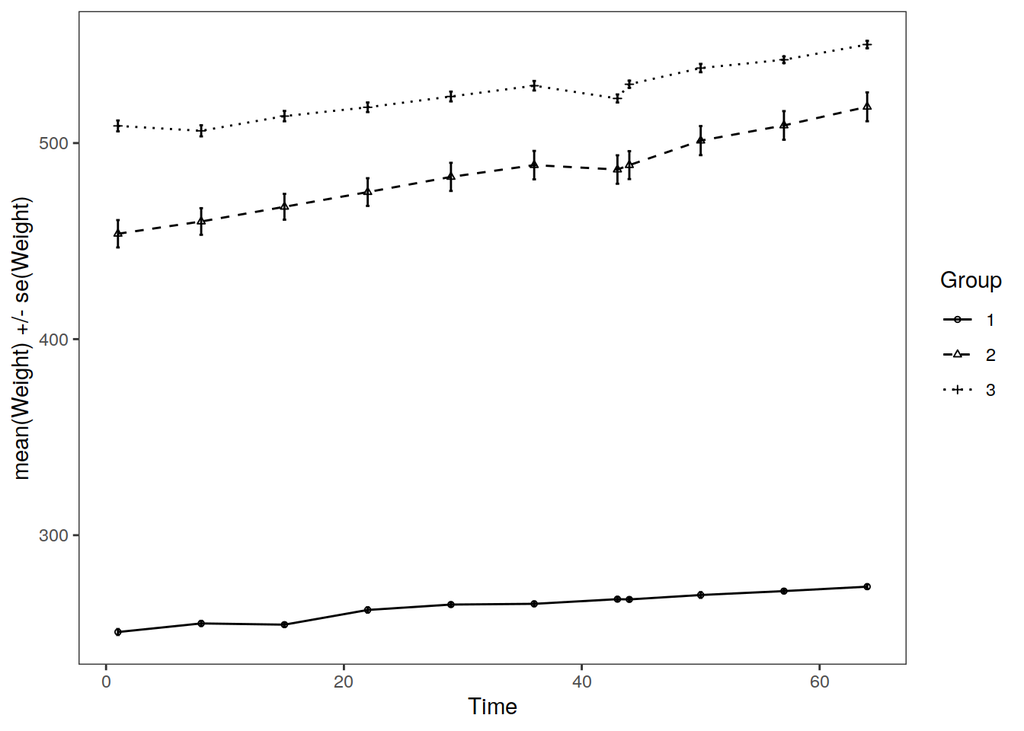

```r
p1 <- ggplot(RATSS, aes(x = Time, y = mean, linetype = Group, shape = Group))
p2 <- p1 + geom_line() + scale_linetype_manual(values = rep(1:10, times=4))
p3 <- p2 + geom_point(size=1) + scale_shape_manual(values = rep(1:10, times=4))
p4 <- p3 + geom_errorbar(aes(ymin=mean-se, ymax=mean+se, linetype="1"), width=0.3)
p5 <- p4 + theme_bw() + theme(panel.grid.major = element_blank(), panel.grid.minor = element_blank())
p6 <- p5 + scale_y_continuous(name = "mean(Weight) +/- se(Weight)")
p6
```

The graphical summary of the data shows that within the groups the weight varies only by little. Overtime, group 1 has almost no increase, while group 2 and 3 increase more significantly. Group 2 varies the most, in fact it is the only data for which the errorbars are easy to spot by eye. Step by step we can condense the data further into more concise graphs:

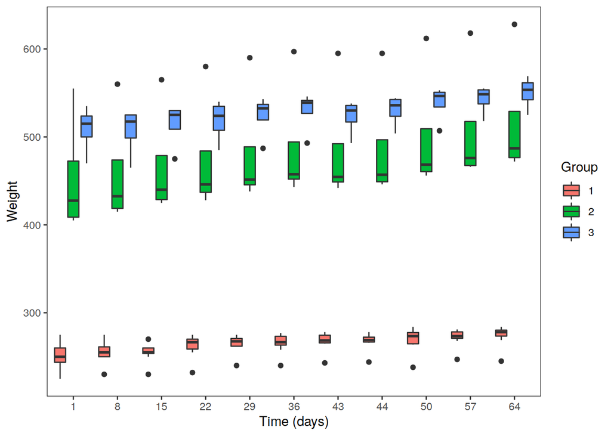

```r
p1 <- ggplot(RATS, aes(x = factor(Time), y = Weight, fill = Group))
p2 <- p1 + geom_boxplot(position = position_dodge(width = 0.9))
p3 <- p2 + theme_bw() + theme(panel.grid.major = element_blank(), panel.grid.minor = element_blank())
p4 <- p3 + scale_x_discrete(name = "Time (days)")
p4
```

The rows of boxplots show that all groups contain outliers, or in this case one rat is an outlier for each groups. Nevertheless, it once more confirms earlier suspicions and so does the following even simpler graph:

```r
# Make a summary data of the post treatment weeks (1-8)
RATS8S <- RATS %>% filter(Time > 0) %>% group_by(Group, ID) %>% summarise( mean=mean(Weight) ) %>% ungroup()
glimpse(RATS8S)
```

```
## Rows: 16
## Columns: 3
## $ Group <fct> 1, 1, 1, 1, 1, 1, 1, 1, 2, 2, 2, 2, 3, 3, 3, 3
## $ ID    <fct> 1, 2, 3, 4, 5, 6, 7, 8, 9, 10, 11, 12, 13, 14, 15, 16
## $ mean  <dbl> 261.0909, 237.6364, 260.1818, 266.5455, 269.4545, 274.7273, 274…
```

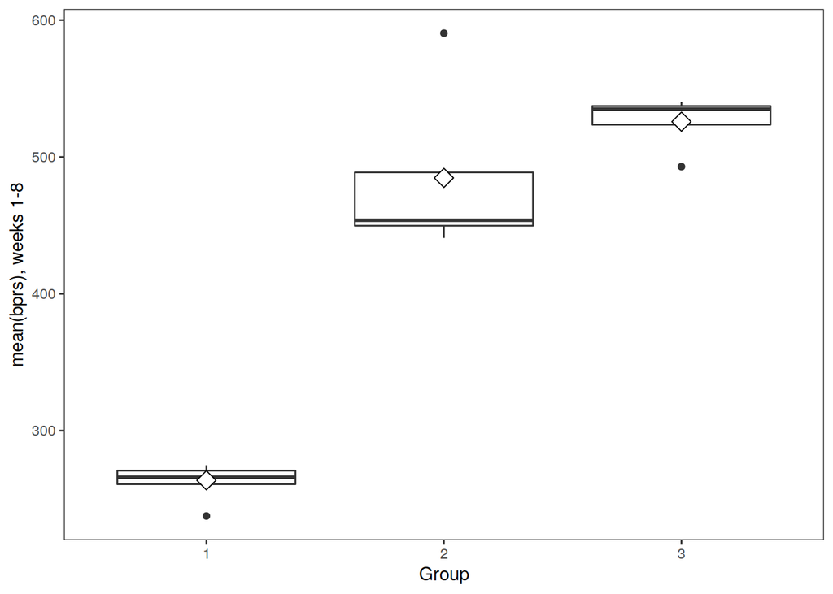

```r
p1 <- ggplot(RATS8S, aes(x = Group, y = mean))
p2 <- p1 + geom_boxplot()
p3 <- p2 + theme_bw() + theme(panel.grid.major = element_blank(), panel.grid.minor = element_blank())
p4 <- p3 + stat_summary(fun.y = "mean", geom = "point", shape=23, size=4, fill = "white")
p5 <- p4 + scale_y_continuous(name = "mean(bprs), weeks 1-8")
p5
```

So lets see what happens if we remove these outliers:

```r
RATS8S1 <- RATS8S %>% filter( (mean > 240 & Group == 1) | (mean < 480 & Group == 2) | (mean > 500 & Group == 3) )
glimpse(RATS8S1)
```

```
## Rows: 13
## Columns: 3
## $ Group <fct> 1, 1, 1, 1, 1, 1, 1, 2, 2, 2, 3, 3, 3
## $ ID    <fct> 1, 3, 4, 5, 6, 7, 8, 9, 10, 11, 14, 15, 16
## $ mean  <dbl> 261.0909, 260.1818, 266.5455, 269.4545, 274.7273, 274.6364, 265…
```

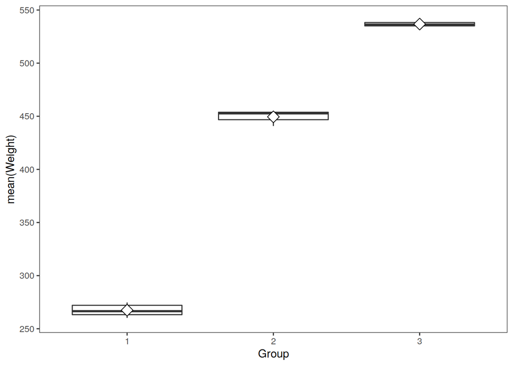

```r
p1 <- ggplot(RATS8S1, aes(x = Group, y = mean))
p2 <- p1 + geom_boxplot()
p3 <- p2 + theme_bw() + theme(panel.grid.major = element_blank(), panel.grid.minor = element_blank())
p4 <- p3 + stat_summary(fun = "mean", geom = "point", shape=23, size=4, fill = "white")
p5 <- p4 + scale_y_continuous(name = "mean(Weight)")
p5
```

## c) Make a fit

After removal of the outliers it becomes obvious that all the variance in Group 2 was basically caused by this one outlier. With a precise summary of our data at hand we can go ahead and see if we can fit a model onto it:

```r
# For establishing a baseline raw data is needed
RATSRAW <- read.csv("https://raw.githubusercontent.com/KimmoVehkalahti/MABS/master/Examples/data/rats.txt", stringsAsFactors = F, sep =  "\t")
# Once again remove outliers
RATSRAW <- RATSRAW  %>% filter( (! ID == 2) & (! ID == 12) & (! ID == 13) )
baseline <- RATSRAW$WD1
RATS8S2 <- RATS8S1 %>%
  mutate(baseline)
# Fit the ANCOVA model and see the results:
fit <- lm(mean ~ baseline + Group, data = RATS8S2)
summary(fit)
```

```
##
## Call:
## lm(formula = mean ~ baseline + Group, data = RATS8S2)
##
## Residuals:
##     Min      1Q  Median      3Q     Max
## -6.0310 -2.6287  0.1002  1.8269  7.1808
##
## Coefficients:
##             Estimate Std. Error t value Pr(>|t|)
## (Intercept) 201.1903    25.7382   7.817 2.66e-05 ***
## baseline      0.2605     0.1010   2.580   0.0297 *
## Group2      138.8380    17.0411   8.147 1.91e-05 ***
## Group3      199.6530    27.1916   7.342 4.36e-05 ***
## ---
## Signif. codes:  0 '***' 0.001 '**' 0.01 '*' 0.05 '.' 0.1 ' ' 1
##
## Residual standard error: 4.669 on 9 degrees of freedom
## Multiple R-squared:  0.9989, Adjusted R-squared:  0.9985
## F-statistic:  2692 on 3 and 9 DF,  p-value: 1.324e-13
```

```r
anova(fit)
```

```
## Analysis of Variance Table
##
## Response: mean
##           Df Sum Sq Mean Sq  F value    Pr(>F)
## baseline   1 174396  174396 7999.137 1.384e-14 ***
## Group      2   1707     853   39.147 3.628e-05 ***
## Residuals  9    196      22
## ---
## Signif. codes:  0 '***' 0.001 '**' 0.01 '*' 0.05 '.' 0.1 ' ' 1
```

E voilá, **finally** we have a model with very good significance!

## 2. BPRS data

### a) Read in data:

```r
BPRS <- read.csv("data/bprs.csv", row.names = 1, header= TRUE)
glimpse(RATS)
```

[output not shown]

```r
str(RATS)
```

[output not shown]